# Vector-Base Recommendations Part I: Representing Customers & Customers as Vectors

```r
library(tidyverse)
library(plotly)
library(knitr)
```

# Content-based filtering recommender in R (theory)

Suppose that we have the following products:

```r
product_data %>% select( product_id, product_desc) %>% kable()
```

| product_id | product_desc |
| --- | --- |
| product_1 | red, green, green, green |
| product_2 | red, blue, green |
| product_3 | blue, blue, blue |
| product_4 | red, red, blue |

We can represent each product as a vector of words/attributes (*red*, *blue*, *green*):

```r
product_data %>% select( product_id, product_desc, tf_red, tf_blue, tf_green) %>% kable()
```

[output not shown]

Here are these four product vectors plotted in the product space:

[output not shown]

[interactive chart not shown]

In the language of *information retrieval*, these are called *term frequency* vectors, since they are counts of word occurrence in the bag-of-words describing each product.

The smaller the angle $\theta$ between any 2 product vectors, the more similar those 2 products are. Because we are only concerned with angle, we can scale each of the product vectors to have length 1 (L2 norm).

Here are the same product vectors in the product space (scaled to have L2 unit length):

[interactive chart not shown]

The angles (in degrees) between the product vectors are:

```
##      rggg rbg bbb rrb
## rggg    0  43  90  74
## rbg    43   0  55  39
## bbb    90  55   0  63
## rrb    74  39  63   0
```

The cosine of the angle $\theta$ between 2 vectors gives a convenient metric for measuring similarity between the 2 vectors, since $cos(\theta)$ lies within the range [0,1]:

| $cos(\theta)$ | meaning |
| --- | --- |
| 1 | vectors point in an identical direction (they are the same vector) |
| 0 | vectors are orthogonal ($90^\circ$) |

Since in this context vectors are non-negative valued, only angles in $\theta\in[0^\circ,90^\circ]$ are possible

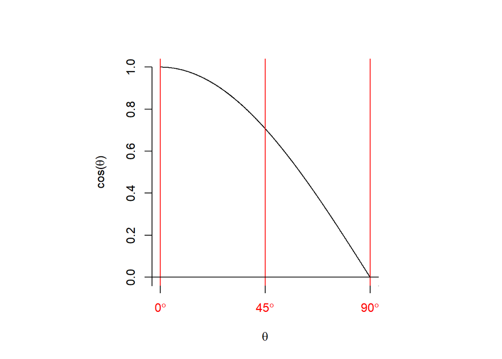

The cosine similarities between the product vectors are:

```
##           rggg       rbg       bbb       rrb
## rggg 1.0000000 0.7302967 0.0000000 0.2828427
## rbg  0.7302967 1.0000000 0.5773503 0.7745967
## bbb  0.0000000 0.5773503 1.0000000 0.4472136
## rrb  0.2828427 0.7745967 0.4472136 1.0000000
```

Suppose now that a customer has bought the following products:

| Product | Red | Blue | Green | n_bought |
| --- | --- | --- | --- | --- |
| product_2 | 1 | 1 | 1 | 1 |
| product_4 | 2 | 1 | 0 | 1 |

We can represent this customer as a vector in the product-vector space by averaging over these 2 product vectors that the customer has bought:

$$\begin{array}{lcl}
\overset{\rightarrow{}}{\text{customer}}_i &=& (\displaystyle\frac{1+2}{2} \space,\space \frac{1+1}{2} \space,\space \frac{1+0}{2})\\
&=& ( 1.5 \space,\space 1 \space,\space 0.5 )
\end{array}$$

Here is the customer plotted in the product-vector space:

[interactive chart not shown]

Suppose instead that the customer had bought 2 of product_4:

| Product | Red | Blue | Green |
| --- | --- | --- | --- |
| product_2 | 1 | 1 | 1 |
| product_4 | 2 | 1 | 0 |
| product_4 | 2 | 1 | 0 |

The customer vector is now:

$$\begin{array}{lcl}
\overset{\rightarrow{}}{\text{customer}}_i &=& (\displaystyle\frac{1+2+2}{3} \space,\space \frac{1+1+1}{3} \space,\space \frac{1+0+0}{3})\\
&=& ( 1.67 \space,\space 1 \space,\space 0.33 )
\end{array}$$

Here is the customer (under this new scenario) plotted in the product-vector space:

[interactive chart not shown]

The angle (in degrees) between the customer vector and each of the product vectors is:

```
## $`customer angle to product vector1: (rggg)`
##          [,1]
## [1,] 64.68351
##
## $`customer angle to product vector2: (rbg)`
##          [,1]
## [1,] 28.56083
##
## $`customer angle to product vector3: (bbb)`
##          [,1]
## [1,] 59.52964
##
## $`customer angle to product vector4: (rrb)`
##         [,1]
## [1,] 10.6707
```

Suppose now that we want to recommend one of the following 2 products to this customer:

| Product | Red | Blue | Green | angle $\theta$ between customer & product vectors | $cos(\theta)$ |
| --- | --- | --- | --- | --- | --- |
| product_5 | 0 | 1 | 1 | $61^\circ$ | 0.4780914 |
| product_6 | 1 | 1 | 0 | $17^\circ$ | 0.9561829 |

Because the angle between the customer vector and the *product_6* vector is smaller than the angle between the customer vector and *product_5*, we’d recommend *product_6* to them. We could have also made this decision based on $cos(\theta)$ being larger - this metric is called the *cosine similarity*.

Customer purchase history:

| Product | Red | Blue | Green |
| --- | --- | --- | --- |
| product_2 | 1 | 1 | 1 |
| product_4 | 2 | 1 | 0 |
| product_4 | 2 | 1 | 0 |

Customer vector:

| Red | Blue | Green |
| --- | --- | --- |
| 1.67 | 1 | 0.33 |

Here are these vectors plotted in the product space:

[interactive chart not shown]

# Inverse Document Frequency (I.D.F.)

If some words are more frequent than others (i.e. some words appears in many products, and some words only in a small number of products), then these common words can dominate in this word vector framework. For example, if a customer has bought lots of products with the word *black* in their product description, then the customer should not be described as having a preference for the colour *black* if the word *black* appears in almost all of the products.

A commonly heuristic used to combat this behaviour is *inverse document frequency (IDF)*.

*IDF* doesn’t have a single definition, but instead many variants (see examples at https://en.wikipedia.org/wiki/Tf-idf).

The definition of *IDF* used by the python library *scikit-learn* (when using the default settings) is

$$\begin{array}{lcl}
idf(w) &=& log\Bigg(\displaystyle\frac{1+n}{1+df(w)}\Bigg) \\
w &=& \text{particular word under consideration} \\
n &=& \text{total number of products} \\
df(w) &=& \text{total number of products containing this word}
\end{array}$$

[https://scikit-learn.org/stable/modules/feature_extraction.html#text-feature-extraction]

*IDF* upweights words that are rare and downweights words that are common.

Here is how this *IDF* function looks for a database of 1000 different unique products:

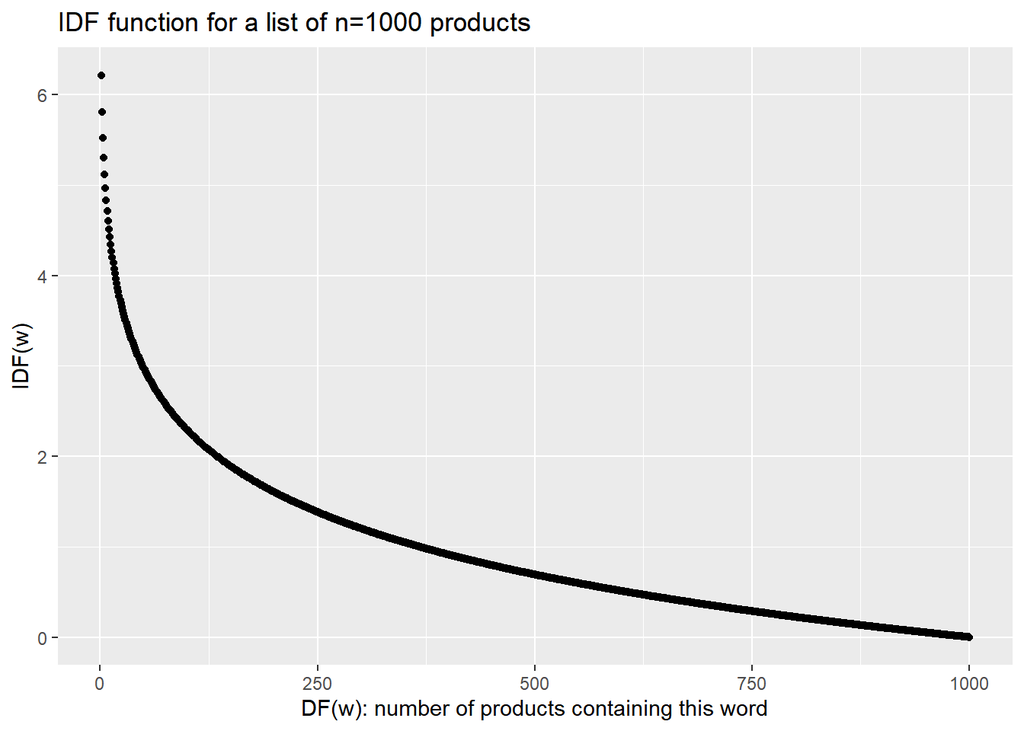

Here is how the inclusion of *IDF* affects our product vectors:

[output not shown]

Each element (word entry) of a product vector is now the term frequency (number of times a word appears in this product) times the *IDF* for this word (scaling for word rarity).

Here is how the *TF-IDF*-transformed product vectors look in product space (all vectors are normalised to have L2 unit length) :

[interactive chart not shown]

Notice that the influence of the word *green* is stronger than the influence of the words *blue* or *red*. For example, the product “RedBlueGreen” has a smaller angle with the *green* axis than it does with the *blue* or *red* axes.